# Calculations for Multielectron Atoms

Author

Daniel Fischer

# Introduction

For helium and heavier atoms, there is no exact (analytical) theoretical treatment possible due to the electron-electron interactions. Unlike the hydrogen atom, where we have a simple two-body problem (electron and nucleus) that can be solved exactly, multielectron atoms present a many-body problem that cannot be solved analytically. The difficulty arises because each electron interacts not only with the nucleus but also with all other electrons simultaneously, creating a complex web of coupled interactions.

The challenge is fundamentally mathematical: while the Schrödinger equation for a hydrogen-like system separates into independent coordinates, the electron-electron repulsion terms prevent such separation in multielectron atoms. The potential energy includes terms like:

$$V = -\sum_i \frac{Ze^2}{4\pi\varepsilon_0 r_i} + \sum_{i<j} \frac{e^2}{4\pi\varepsilon_0 |\vec{r}_i - \vec{r}_j|}$$

where the first sum represents electron-nucleus attraction and the second represents electron-electron repulsion. These coupled repulsion terms make exact solutions impossible.

Two main possibilities exist for treating multielectron atoms:

1. **Numerical methods** (often called “black box” approaches): These use computational techniques to solve the Schrödinger equation numerically without providing much physical insight into the electronic structure.
2. **Approximation methods**: These introduce physically motivated simplifications that both make the problem tractable and provide intuitive understanding of atomic structure.

In this chapter, we discuss several approximation methods that provide physical insight into the electronic structure of atoms. Each method represents a different balance between accuracy and computational simplicity, and understanding these approximations is essential for interpreting atomic spectra and chemical properties.

# 1. The Independent Electron Model

The independent electron model is the simplest approximation for treating multielectron atoms. It provides a foundation for understanding more sophisticated methods while already capturing essential physics.

The independent electron model considers an electron $e_i$ in a many-electron atom. Its electron-electron interaction potential is given by:

$$E_{\text{pot}}(\vec{r}_i) = \frac{e^2}{4\pi\varepsilon_0} \sum_{j \neq i} \frac{1}{|\vec{r}_i - \vec{r}_j|}$$

This expression represents the instantaneous Coulomb repulsion between electron $i$ and all other electrons in the atom. However, calculating this exactly would require knowing the positions of all other electrons at all times, which brings us back to the unsolvable many-body problem.

In the independent electron model, the interaction is not explicitly accounted for, but it is implicitly included through an effective potential $\phi_{\text{eff}}(\vec{r})$. This potential represents the average field experienced by an electron due to the nucleus and all other electrons. The key assumption is that each electron moves independently in this average field.

This approach leads to a reduction to many one-electron problems. The wave function of each electron can be written as:

$$\psi(\vec{r}_i) = R(r_i) Y_{\ell m}(\theta_i, \phi_i)$$

where the radial part $R(r_i)$ and the angular part $Y_{\ell m}$ (spherical harmonics) are separated. The solutions (eigenenergies $E_i(n_i, \ell_i, m_i, m_{s_i})$) depend on the same quantum numbers as hydrogen, but the actual values differ because the effective potential differs from the pure Coulomb potential.

## 1.1 Key Features of the Independent Electron Model

- The angular part is identical to the Coulomb-potential case (hydrogen-like), preserving the spherical symmetry of the problem
- The radial part depends on the effective potential and must be determined for each specific atom
- Solutions maintain the same quantum number structure as hydrogen: principal quantum number $n$, orbital angular momentum $\ell$, magnetic quantum number $m$, and spin $m_s$
- The effective potential approach transforms an intractable many-body problem into $N$ solvable one-body problems

## 1.2 Example: A “Reasonable” Effective Potential (Electrostatic Case)

To make the independent electron model concrete, we need to specify what constitutes a “reasonable” effective potential. Consider the electrostatic case where we construct the potential from first principles.

For electron $i$ at position $\vec{r}_i$, the effective potential should account for:  
- The attractive potential from the nucleus (charge $+Ze$)  
- The repulsive potential from all other electrons

To make the independent electron model concrete, we need to specify what constitutes a “reasonable” effective potential. Consider the electrostatic case where we construct the potential from first principles.

For electron $i$ at position $\vec{r}_i$, the effective potential should account for:  
- The attractive potential from the nucleus (charge $+Ze$)  
- The repulsive potential from all other electrons

A reasonable electrostatic effective potential can be written as:

$$\phi_{\text{eff}}(r_i) = \frac{e}{4\pi\varepsilon_0} \left[\frac{Z}{r_i} - \sum_{j \neq i} \int \frac{1}{|\vec{r}_i - \vec{r}_j|} |\psi_j(\vec{r}_j)|^2 d^3r_j\right]
\tag{1}$$

**Physical interpretation:**  
- The first term $Z/r_i$ represents the full nuclear attraction  
- The integral term represents the average repulsion from electron $j$, weighted by its probability density $|\psi_j(\vec{r}_j)|^2$  
- The sum over $j \neq i$ includes contributions from all other electrons  
- This is an *average* potential because the electron probability distributions $|\psi_j|^2$ represent time-averaged positions

This formulation reveals an inherent self-consistency requirement: the effective potential depends on the wave functions $\psi_j$ of all other electrons, but these wave functions are themselves solutions to Schrödinger equations that depend on the effective potential. This circular dependence motivates the self-consistent field methods discussed in Section 2.

**Key approximation:** This effective potential treats electron-electron interactions in an average sense, neglecting instantaneous correlations between electron positions. Despite this simplification, it captures the essential screening effect where inner electrons reduce the effective nuclear charge experienced by outer electrons.

# 2. The Hartree–Fock Method

The **Hartree–Fock method** refines the independent-electron approach by determining the effective potential *self-consistently*. Instead of assuming a fixed average potential, we now **iteratively** solve for both the potential and the electron wave functions until they are mutually consistent.

In essence, the method enforces that each electron moves in the *average field created by all electrons*, including itself in a properly symmetrized way that respects the **Pauli exclusion principle**.

## 2.1 The Ansatz

We start by guessing a spherically symmetric effective potential for a single electron:

$$\phi^{(0)}(\vec{r}) = \frac{-e}{4\pi\varepsilon_0}\left(\frac{Z}{r} - S(r)\right)$$

Here,  
- the first term $Z/r$ describes the **nuclear attraction**, and  
- the function $S(r)$ represents an **effective screening** due to the other electrons.

The idea is that near the nucleus, the electron experiences the full nuclear charge (since inner electrons do not shield much), while at large distances, the effective charge is reduced by the screening effect of inner electrons.

## 2.2 Visualizing the Effective Potential

The diagram below compares the Coulomb potential for different nuclear charges and a **screened potential** that transitions smoothly between them.

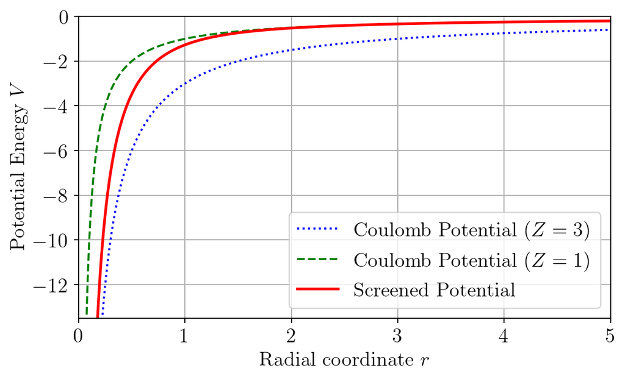

```python
import numpy as np
import matplotlib.pyplot as plt

plt.rcParams['text.usetex'] = True
plt.rcParams['font.family'] = 'serif'
plt.rcParams['font.size'] = 15

def coulomb_potential(Z, r):
    return -Z / r

def screened_potential(Z_core, Z_val, r, screening_length):
    return -Z_core / r * np.exp(-r / screening_length) - Z_val / r * (1 - np.exp(-r / screening_length))

fig, ax = plt.subplots(figsize=(7, 4))
ax.set_xlabel(r'Radial coordinate $r$')
ax.set_ylabel(r'Potential Energy $V$')
ax.set_ylim(-13.5, 0)
ax.set_xlim(0, 5)
ax.grid(True)

r = np.linspace(0.01, 5, 400)

V_Z3 = coulomb_potential(Z=3, r=r)
ax.plot(r, V_Z3, label=r'Coulomb Potential ($Z=3$)', color='blue',  linestyle=':')

V_Z1 = coulomb_potential(Z=1, r=r)
ax.plot(r, V_Z1, label=r'Coulomb Potential ($Z=1$)', color='green', linestyle='--')

Z_core = 3
Z_val = 1
screening_length = 0.5
V_screened = screened_potential(Z_core, Z_val, r, screening_length)
ax.plot(r, V_screened, label='Screened Potential', color='red', linestyle='-', linewidth=2)

ax.legend()
plt.show()
```

As expected:  
- for **small $r$**, the potential approaches the full nuclear attraction ($-Z/r$);  
- for **large $r$**, it behaves as if only a single effective charge $Z_{\text{eff}}$ acts on the electron;  
- in between, the screening term $S(r)$ smoothly reduces the attraction.

## 2.3 Self-Consistent Iteration

Once an initial potential $\phi^{(0)}(\vec{r})$ is chosen, we solve the one-electron Schrödinger equation:

$$\hat{H}^{(0)} \psi_i^{(0)}(\vec{r}) = E_i^{(0)} \psi_i^{(0)}(\vec{r}),$$

with

$$\hat{H}^{(0)} = -\frac{\hbar^2}{2m_e} \nabla^2 - e \, \phi^{(0)}(\vec{r}).$$

The resulting wave functions $\psi_i^{(0)}$ define **electron probability densities**  
$|\psi_i^{(0)}(\vec{r})|^2$, which can be used to compute an *improved* effective potential:

$$\phi^{(1)}(\vec{r}) = \frac{e}{4\pi\varepsilon_0}\left[\frac{Z}{r} - \sum_{j} \int \frac{|\psi_j^{(0)}(\vec{r}')|^2}{|\vec{r} - \vec{r}'|} \, d^3r' \right].$$

This new potential $\phi^{(1)}$ is then used to solve the Schrödinger equation again, producing new wave functions $\psi_i^{(1)}$.  
The process is repeated until convergence, i.e.,

$$\phi^{(n+1)}(\vec{r}) \approx \phi^{(n)}(\vec{r}).$$

At that point, the potential and the set of orbitals are **self-consistent**.

The following flowchart summarizes the **iterative Hartree–Fock procedure**:

[output not shown]

> **Note:**  
> While this iterative process can be computationally intensive, it provides a self-consistent set of single-particle orbitals that best approximate the true many-electron wavefunction in the mean-field sense.

## 2.4 The Exchange Term (Fock Correction)

The iterative procedure described so far is the Hartree method, and the wave function is constructed as a simple product of single-electron functions

$$\Psi(\vec{r}_1, \vec{r}_2, \ldots, \vec{r}_N) = \psi_1(\vec{r}_1) \psi_2(\vec{r}_2) \cdots \psi_N(\vec{r}_N).$$

However, electrons are **indistinguishable fermions**, and the **Pauli principle** requires the total wave function to be *antisymmetric* under exchange of any two electrons.

To enforce this, the Hartree–Fock method replaces the product state by a **Slater determinant**:

$$\Psi_{\text{HF}}(\vec{r}_1, \vec{r}_2, \dots, \vec{r}_N)
= \frac{1}{\sqrt{N!}}
\begin{vmatrix}
\psi_1(\vec{r}_1) & \psi_2(\vec{r}_1) & \dots & \psi_N(\vec{r}_1) \\
\psi_1(\vec{r}_2) & \psi_2(\vec{r}_2) & \dots & \psi_N(\vec{r}_2) \\
\vdots & \vdots & \ddots & \vdots \\
\psi_1(\vec{r}_N) & \psi_2(\vec{r}_N) & \dots & \psi_N(\vec{r}_N)
\end{vmatrix}$$

**Example for 2 electrons:**

$$\begin{vmatrix}
\psi_1(\vec{r}_1) & \psi_2(\vec{r}_1) \\
\psi_1(\vec{r}_2) & \psi_2(\vec{r}_2)
\end{vmatrix} = \psi_1(\vec{r}_1)\psi_2(\vec{r}_2) - \psi_2(\vec{r}_1)\psi_1(\vec{r}_2)$$

This antisymmetrization introduces an additional **exchange interaction** term — a purely quantum-mechanical correction with no classical analogue. It ensures that two electrons with the same spin avoid each other in space, lowering their Coulomb repulsion energy.

## 2.5 Summary of the Hartree–Fock Scheme

1. **Start** with an initial guess for the potential $\phi^{(0)}(\vec{r})$.
2. **Solve** the one-electron Schrödinger equation to obtain orbitals $\psi_i^{(0)}$.
3. **Compute** a new effective potential using the resulting charge density.
4. **Include** the exchange term to respect antisymmetry.
5. **Iterate** until the potential and orbitals converge.

> **In short:**  
> The Hartree–Fock method finds a *self-consistent, antisymmetrized mean-field solution* for many-electron atoms.  
> It is not exact, but it provides a systematic and physically meaningful way to include both **screening** and **exchange** effects — two key features of real atomic systems.

# 3. Configuration Interaction

The **Hartree–Fock method** provides a powerful mean-field description of multielectron atoms. However, it neglects **electron correlation**, i.e., the instantaneous interaction between electrons beyond the averaged Coulomb potential. To improve upon this, we can go beyond a single Slater determinant and express the total wave function as a **linear combination of multiple determinants**, each representing a different electron configuration:

$$\Psi(\vec{r}, s) = \sum_k c_k\, \mathcal{Y}_k$$

Here,  
- $\mathcal{Y}_k$ denotes the $k$-th **configuration** (a Slater determinant built from a specific set of one-electron orbitals), and  
- $c_k$ are **expansion coefficients** that determine the contribution of each configuration to the total wavefunction.

This approach is known as the **Configuration Interaction (CI) method**.  
It systematically includes *mixing* between different configurations, allowing the resulting state to better approximate the true correlated motion of the electrons.

## 3.1 Energy Calculation

To find the energy associated with this mixed wavefunction, we insert the expansion into the expectation value of the Hamiltonian:

$$E = \langle \Psi | \hat{H} | \Psi \rangle$$

Substituting $\Psi = \sum_k c_k \mathcal{Y}_k$ gives

$$E = \sum_{i,k} c_i^* c_k \langle \mathcal{Y}_i | \hat{H} | \mathcal{Y}_k \rangle
= \sum_{i,k} c_i^* H_{ik} c_k$$

where the matrix elements

$$H_{ik} = \langle \mathcal{Y}_i | \hat{H} | \mathcal{Y}_k \rangle$$

form the **Hamiltonian matrix** in the basis of configuration states.

Because the $\mathcal{Y}_k$ are not true eigenstates of the full Hamiltonian $\hat{H}$, the **off-diagonal terms** $H_{ik}$ (with $i \neq k$) are nonzero. Diagonalizing the Hamiltonian matrix yields a set of **eigenvalues** (new energy levels) and **eigenvectors** (improved, correlated wavefunctions):

$$H \mathbf{c} = E \mathbf{c}$$

This procedure allows configurations to mix in a way that lowers the total energy — a direct manifestation of electron correlation. In practice, the CI method can yield highly accurate results, though the number of configurations grows rapidly with system size.

> **In short:** Configuration Interaction captures the effects of electron correlation by combining multiple Slater determinants into a single variationally optimized wavefunction.

# 4. Summary

The theoretical treatment of multielectron atoms requires a hierarchy of approximations that balance **accuracy** and **computational effort**:

1. **Independent-Electron Model:**
   - Simplest approximation.
   - Each electron moves in an average potential representing the attraction to the nucleus and repulsion from other electrons.
   - Neglects antisymmetry and correlation effects.
2. **Hartree–Fock Method:**
   - Introduces a **self-consistent field**.
   - The total wavefunction is represented by a **single Slater determinant**, ensuring proper antisymmetrization.
   - Includes exchange interaction but not full electron correlation.
   - Strikes a practical balance between accuracy and computational cost.
3. **Configuration Interaction (CI):**
   - Expands the total wavefunction as a **linear combination of multiple configurations**.
   - Accounts for **electron correlation** by allowing configuration mixing.
   - Provides the most accurate results, but with a steep increase in computational complexity.

> **In summary:**  
> Each level of approximation builds upon the previous one. The Independent-Electron Model provides a starting point, Hartree–Fock refines it with exchange and antisymmetry, and Configuration Interaction further improves it by including correlation effects — at the cost of significantly greater computational effort.